IE 7300: Statistical learning for Engineering

# Project check point #3

Weihua Pan

206-822-8347

pan.weih@northeastern.edu

Percentage of Effort Contributed by Student : 100%  
Signature of Student : Weihua Pan  
Submission Date: 11/28/2023

```python
import pandas as pd
import numpy as np
import matplotlib.pyplot as plt

pd.set_option('display.max_columns',30)
```

# a) Problem Statement

## Clearly define the problem statement

**Problem statement **: To determine whether some features of Mushroom,such as `cap diameter`, `cap shape` and `cap color`,can be used to predict its edibility.****

## State your hypothesis

**Hypothesis **: Mushrooms with specify feature characteristic are more likely to be edible or poisonous.****

# Dataset

## Present the dataset and include a data dictionary

```python
df = pd.read_csv("MushroomDataset/secondary_data.csv",sep=";")
df.info()
df.head()
```

```
<class 'pandas.core.frame.DataFrame'>
RangeIndex: 61069 entries, 0 to 61068
Data columns (total 21 columns):
 #   Column                Non-Null Count  Dtype
---  ------                --------------  -----
 0   class                 61069 non-null  object
 1   cap-diameter          61069 non-null  float64
 2   cap-shape             61069 non-null  object
 3   cap-surface           46949 non-null  object
 4   cap-color             61069 non-null  object
 5   does-bruise-or-bleed  61069 non-null  object
 6   gill-attachment       51185 non-null  object
 7   gill-spacing          36006 non-null  object
 8   gill-color            61069 non-null  object
 9   stem-height           61069 non-null  float64
 10  stem-width            61069 non-null  float64
 11  stem-root             9531 non-null   object
 12  stem-surface          22945 non-null  object
 13  stem-color            61069 non-null  object
 14  veil-type             3177 non-null   object
 15  veil-color            7413 non-null   object
 16  has-ring              61069 non-null  object
 17  ring-type             58598 non-null  object
 18  spore-print-color     6354 non-null   object
 19  habitat               61069 non-null  object
 20  season                61069 non-null  object
dtypes: float64(3), object(18)
memory usage: 9.8+ MB
```

|  | class | cap-diameter | cap-shape | cap-surface | cap-color | does-bruise-or-bleed | gill-attachment | gill-spacing | gill-color | stem-height | stem-width | stem-root | stem-surface | stem-color | veil-type | veil-color | has-ring | ring-type | spore-print-color | habitat | season |
| --- | --- | --- | --- | --- | --- | --- | --- | --- | --- | --- | --- | --- | --- | --- | --- | --- | --- | --- | --- | --- | --- |
| 0 | p | 15.26 | x | g | o | f | e | NaN | w | 16.95 | 17.09 | s | y | w | u | w | t | g | NaN | d | w |
| 1 | p | 16.60 | x | g | o | f | e | NaN | w | 17.99 | 18.19 | s | y | w | u | w | t | g | NaN | d | u |
| 2 | p | 14.07 | x | g | o | f | e | NaN | w | 17.80 | 17.74 | s | y | w | u | w | t | g | NaN | d | w |
| 3 | p | 14.17 | f | h | e | f | e | NaN | w | 15.77 | 15.98 | s | y | w | u | w | t | p | NaN | d | w |
| 4 | p | 14.64 | x | h | o | f | e | NaN | w | 16.53 | 17.20 | s | y | w | u | w | t | p | NaN | d | w |

The dataset contains 61069 rows and 21 columns. The target variable is class (e or p).

```python
df.select_dtypes(include='object')
```

|  | class | cap-shape | cap-surface | cap-color | does-bruise-or-bleed | gill-attachment | gill-spacing | gill-color | stem-root | stem-surface | stem-color | veil-type | veil-color | has-ring | ring-type | spore-print-color | habitat | season |
| --- | --- | --- | --- | --- | --- | --- | --- | --- | --- | --- | --- | --- | --- | --- | --- | --- | --- | --- |
| 0 | p | x | g | o | f | e | NaN | w | s | y | w | u | w | t | g | NaN | d | w |
| 1 | p | x | g | o | f | e | NaN | w | s | y | w | u | w | t | g | NaN | d | u |
| 2 | p | x | g | o | f | e | NaN | w | s | y | w | u | w | t | g | NaN | d | w |
| 3 | p | f | h | e | f | e | NaN | w | s | y | w | u | w | t | p | NaN | d | w |
| 4 | p | x | h | o | f | e | NaN | w | s | y | w | u | w | t | p | NaN | d | w |
| ... | ... | ... | ... | ... | ... | ... | ... | ... | ... | ... | ... | ... | ... | ... | ... | ... | ... | ... |
| 61064 | p | s | s | y | f | f | f | f | NaN | NaN | y | NaN | NaN | f | f | NaN | d | a |
| 61065 | p | f | s | y | f | f | f | f | NaN | NaN | y | NaN | NaN | f | f | NaN | d | a |
| 61066 | p | s | s | y | f | f | f | f | NaN | NaN | y | NaN | NaN | f | f | NaN | d | u |
| 61067 | p | f | s | y | f | f | f | f | NaN | NaN | y | NaN | NaN | f | f | NaN | d | u |
| 61068 | p | s | s | y | f | f | f | f | NaN | NaN | y | NaN | NaN | f | f | NaN | d | u |

61069 rows × 18 columns

17 of them are categorical feature :['cap-shape', 'cap-surface', 'cap-color', 'does-bruise-or-bleed', 'gill-attachment', 'gill-spacing', 'gill-color', 'stem-root', 'stem-surface', 'stem-color', 'veil-type', 'veil-color', 'has-ring', 'ring-type', 'spore-print-color', 'habitat', 'season']  
I will do one-hot-encode later.

```python
df.select_dtypes(include='number')
```

|  | cap-diameter | stem-height | stem-width |
| --- | --- | --- | --- |
| 0 | 15.26 | 16.95 | 17.09 |
| 1 | 16.60 | 17.99 | 18.19 |
| 2 | 14.07 | 17.80 | 17.74 |
| 3 | 14.17 | 15.77 | 15.98 |
| 4 | 14.64 | 16.53 | 17.20 |
| ... | ... | ... | ... |
| 61064 | 1.18 | 3.93 | 6.22 |
| 61065 | 1.27 | 3.18 | 5.43 |
| 61066 | 1.27 | 3.86 | 6.37 |
| 61067 | 1.24 | 3.56 | 5.44 |
| 61068 | 1.17 | 3.25 | 5.45 |

61069 rows × 3 columns

3 of them are numerical: ['cap-diameter', 'stem-height', 'stem-width'].

### Dataset Dictionary

Target variable: `class` divided in edible=e and poisonous=p

n: nominal, m: metrical  
1. cap-diameter (m): float number in cm 2. cap-shape (n): * bell=b, * conical=c, * convex=x, * flat=f, * sunken=s, * spherical=p, * others=o 3. cap-surface (n): * fibrous=i, * grooves=g, * scaly=y, * smooth=s, * shiny=h, * leathery=l, * silky=k, * sticky=t, * wrinkled=w, * fleshy=e 4. cap-color (n): * brown=n, * buff=b, * gray=g, * green=r, * pink=p, * purple=u, * red=e, * white=w, * yellow=y, * blue=l, * orange=o, * black=k 5. does-bruise-bleed (n): * bruises-or-bleeding=t, * no=f 6. gill-attachment (n): * adnate=a, * adnexed=x, * decurrent=d, * free=e, * sinuate=s, * pores=p, * none=f, * unknown=? 7. gill-spacing (n): * close=c, * distant=d, * none=f 8. gill-color (n): * see cap-color + * none=f 9. stem-height (m): float number in cm 10. stem-width (m): float number in mm 11. stem-root (n): * bulbous=b, * swollen=s, * club=c, * cup=u, * equal=e, * rhizomorphs=z, * rooted=r 12. stem-surface (n): see cap-surface + none=f 13. stem-color (n): see cap-color + none=f 14. veil-type (n): partial=p, universal=u 15. veil-color (n): see cap-color + none=f 16. has-ring (n): * ring=t, * none=f 17. ring-type (n): * cobwebby=c, * evanescent=e, * flaring=r, * grooved=g, * large=l, * pendant=p, * sheathing=s, * zone=z, * scaly=y, * movable=m, * none=f, * unknown=? 18. spore-print-color (n): see cap color 19. habitat (n): * grasses=g, * leaves=l, * meadows=m, * paths=p, * heaths=h, * urban=u, * waste=w, * woods=d 20. season (n): * spring=s, * summer=u, * autumn=a, * winter=w

## Explain how this dataset supports your hypothesis

```python
poison = df[df['class']=='p']
edible = df[df['class']=='e']
```

```python
p_color = poison['cap-color'].value_counts().index
p_counts = poison['cap-color'].value_counts().values
e_color = edible['cap-color'].value_counts().index
e_counts = edible['cap-color'].value_counts().values
```

```python
color_code = {"n":"brown",
             "b":"#f0dc82", #buff
             "g":"gray",
             "r":"green",
             "p":"pink",
             "u":"purple",
             "e":"red",
             "w":"white",
             "y":"yellow",
             "l":"blue",
             "o":"orange",
             "k":"black"}
```

```python
color_map = {"n":"brown",
             "b":"buff", #buff
             "g":"gray",
             "r":"green",
             "p":"pink",
             "u":"purple",
             "e":"red",
             "w":"white",
             "y":"yellow",
             "l":"blue",
             "o":"orange",
             "k":"black"}
```

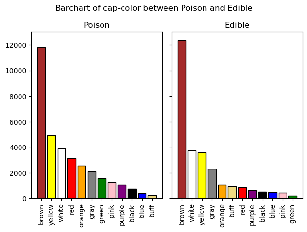

```python
fig,ax = plt.subplots(1,2,sharey=True)


ax[0].bar([color_map[c] for c in p_color],p_counts,color=[color_code[code] for code in p_color],
          edgecolor='black')
ax[0].set_title('Poison')

#
ax[1].bar([color_map[c] for c in e_color],e_counts,color=[color_code[code] for code in e_color],
          edgecolor='black')
ax[1].set_title('Edible')

# rotate xlabels
ax[0].set_xticklabels([color_map[c] for c in p_color],rotation=90)
ax[1].set_xticklabels([color_map[c] for c in e_color],rotation=90)

fig.suptitle("Barchart of cap-color between Poison and Edible")
plt.tight_layout()
plt.show()
```

Using `cap-color` and other features, we are able to find some pattern to classify base on these features. For example, From the above plot, We can see most green and red mushroom are poisonous.

# Exploratory Data Analysis(EDA)

## Descriptive Statistics

```python
df.describe()
```

|  | cap-diameter | stem-height | stem-width |
| --- | --- | --- | --- |
| count | 61069.000000 | 61069.000000 | 61069.000000 |
| mean | 6.733854 | 6.581538 | 12.149410 |
| std | 5.264845 | 3.370017 | 10.035955 |
| min | 0.380000 | 0.000000 | 0.000000 |
| 25% | 3.480000 | 4.640000 | 5.210000 |
| 50% | 5.860000 | 5.950000 | 10.190000 |
| 75% | 8.540000 | 7.740000 | 16.570000 |
| max | 62.340000 | 33.920000 | 103.910000 |

Only 3 columns are numerical.

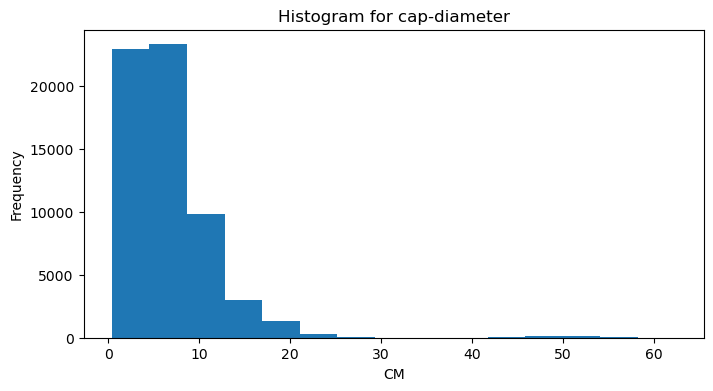

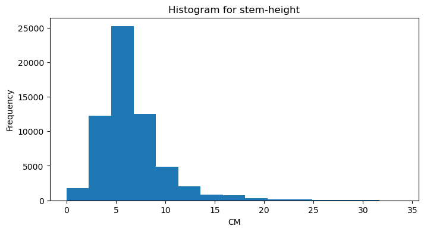

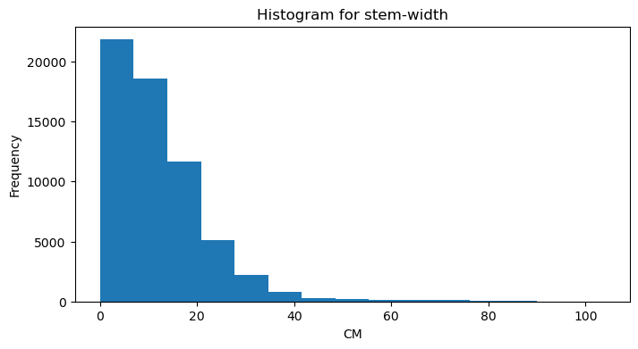

```python
numerical_columns = df.select_dtypes(include='number')

for column in numerical_columns:
    fig, ax = plt.subplots(figsize=(8, 4))
    df[column].plot(kind='hist', title=f"Histogram for {column}", ax=ax,bins=15)
    ax.set_xlabel("CM")
    plt.show()
```

By the histogram plot, we can see `cap-diameter` and `stem-width` are right skewed. And only `stem-height` is normal distributive.

## Bar chart among 2 target variables

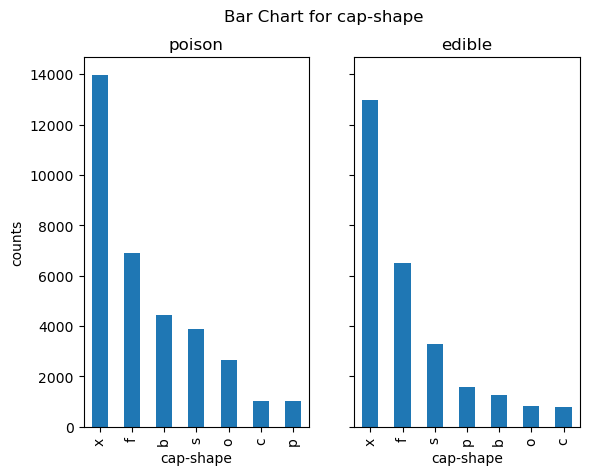

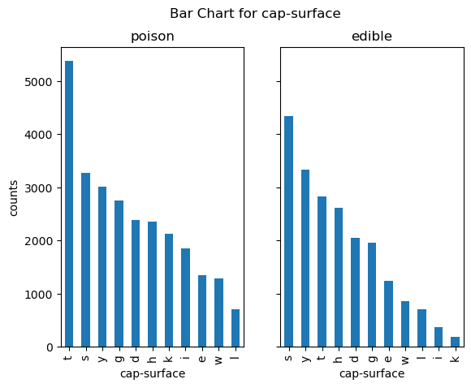

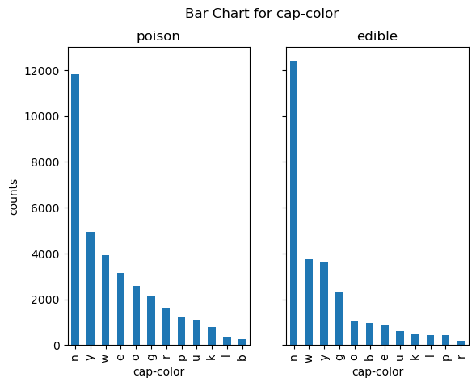

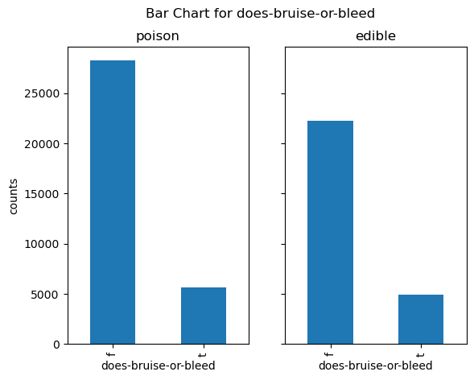

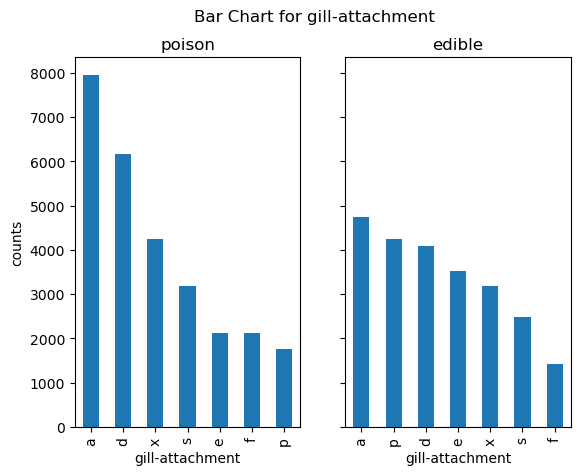

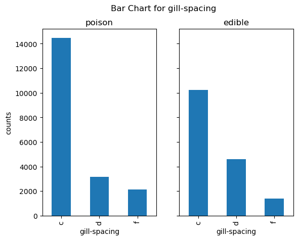

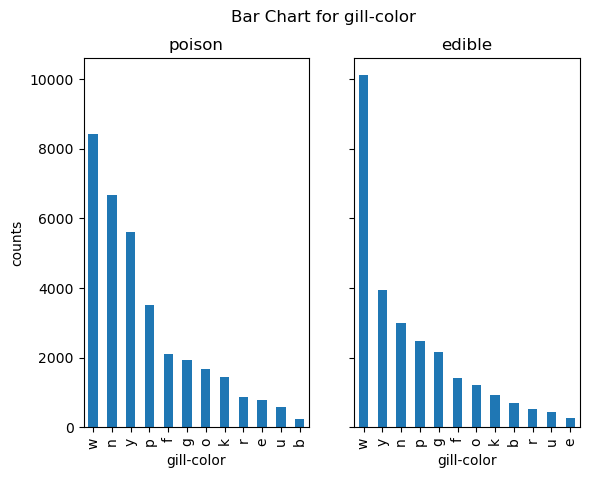

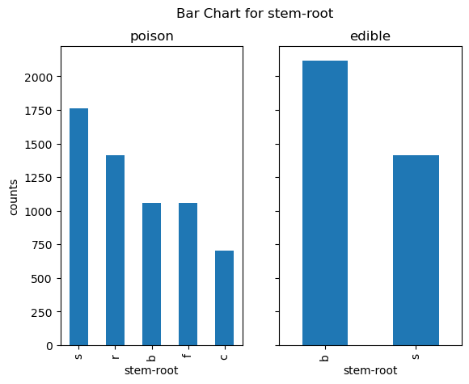

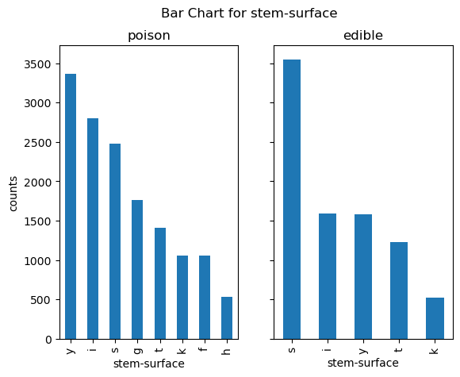

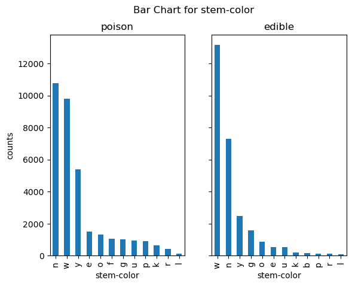

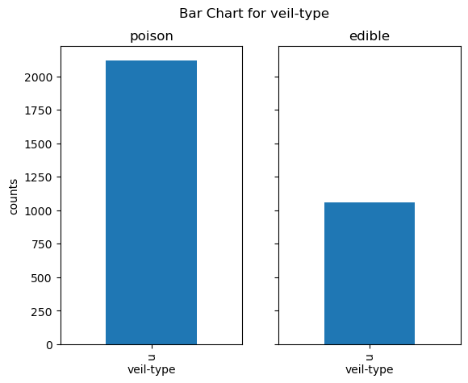

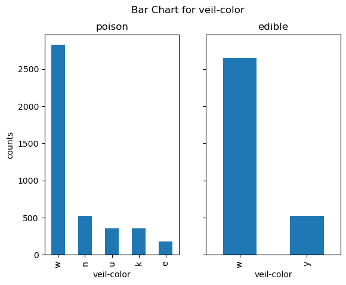

[5 more figures not shown]

```python
object_columns = df.select_dtypes(include=['object']).columns[1:]

for column in object_columns:
    # Count the occurrences of each category
    poison_C = poison[column].value_counts()
    edible_C = edible[column].value_counts()

    # Create a subplot chart
    fig,ax = plt.subplots(1,2,sharey=True)

    poison_C.plot(kind='bar',ax=ax[0],title='poison',ylabel='counts')
    edible_C.plot(kind='bar',ax=ax[1],title='edible')



    fig.suptitle(f'Bar Chart for {column}')

    # Show the plot
    plt.show()
```

By the above bar charts, we can find some pattern to classify poisonous mushroom by categorical features. For example, In `season` bar chart, we can see most poisonous mushrooms live in autumn and summer. And we can find pattern in `veil-color` as well. We can easily classify the mushrooms with yellow veil is edible since there is no poisonous mushroom with yell veil. All the `veil-type` are universal, other than that are missing values.

## Missing values

```python
NA_dict = dict()
for column in df.columns[1:]:
    NA_dict[column] = df[column].isna().sum()

NA_dict
```

```
{'cap-diameter': 0,
 'cap-shape': 0,
 'cap-surface': 14120,
 'cap-color': 0,
 'does-bruise-or-bleed': 0,
 'gill-attachment': 9884,
 'gill-spacing': 25063,
 'gill-color': 0,
 'stem-height': 0,
 'stem-width': 0,
 'stem-root': 51538,
 'stem-surface': 38124,
 'stem-color': 0,
 'veil-type': 57892,
 'veil-color': 53656,
 'has-ring': 0,
 'ring-type': 2471,
 'spore-print-color': 54715,
 'habitat': 0,
 'season': 0}
```

`cap-surface`,`gill-attachment`,`gill-spacing`,`stem-root`,`stem-surface`,`veil-type`,`veil-color`,`ring-type`,`spore-print-color` have missing values. And all of them are categorical. All the missing values here might means unknown or not applicable. I decide to impute them using "?", since I have no idea how these missing values appear and cannot apply imputation strategy like mode or k_nearest. We can let the model to decide and find pattern when they meet the missing values "?".

```python
df= df.fillna('?')
```

## Feature engineering

```python
y = df.iloc[:,0]
X = df.iloc[:,1:]
X = pd.get_dummies(X)
X
```

|  | cap-diameter | stem-height | stem-width | cap-shape_b | cap-shape_c | cap-shape_f | cap-shape_o | cap-shape_p | cap-shape_s | cap-shape_x | cap-surface_? | cap-surface_d | cap-surface_e | cap-surface_g | cap-surface_h | ... | spore-print-color_r | spore-print-color_u | spore-print-color_w | habitat_d | habitat_g | habitat_h | habitat_l | habitat_m | habitat_p | habitat_u | habitat_w | season_a | season_s | … |
| --- | --- | --- | --- | --- | --- | --- | --- | --- | --- | --- | --- | --- | --- | --- | --- | --- | --- | --- | --- | --- | --- | --- | --- | --- | --- | --- | --- | --- | --- | --- |
| 0 | 15.26 | 16.95 | 17.09 | False | False | False | False | False | False | True | False | False | False | True | False | ... | False | False | False | True | False | False | False | False | False | False | False | False | False | … |
| 1 | 16.60 | 17.99 | 18.19 | False | False | False | False | False | False | True | False | False | False | True | False | ... | False | False | False | True | False | False | False | False | False | False | False | False | False | … |
| 2 | 14.07 | 17.80 | 17.74 | False | False | False | False | False | False | True | False | False | False | True | False | ... | False | False | False | True | False | False | False | False | False | False | False | False | False | … |
| 3 | 14.17 | 15.77 | 15.98 | False | False | True | False | False | False | False | False | False | False | False | True | ... | False | False | False | True | False | False | False | False | False | False | False | False | False | … |
| 4 | 14.64 | 16.53 | 17.20 | False | False | False | False | False | False | True | False | False | False | False | True | ... | False | False | False | True | False | False | False | False | False | False | False | False | False | … |
| ... | ... | ... | ... | ... | ... | ... | ... | ... | ... | ... | ... | ... | ... | ... | ... | ... | ... | ... | ... | ... | ... | ... | ... | ... | ... | ... | ... | ... | ... | … |
| 61064 | 1.18 | 3.93 | 6.22 | False | False | False | False | False | True | False | False | False | False | False | False | ... | False | False | False | True | False | False | False | False | False | False | False | True | False | … |
| 61065 | 1.27 | 3.18 | 5.43 | False | False | True | False | False | False | False | False | False | False | False | False | ... | False | False | False | True | False | False | False | False | False | False | False | True | False | … |
| 61066 | 1.27 | 3.86 | 6.37 | False | False | False | False | False | True | False | False | False | False | False | False | ... | False | False | False | True | False | False | False | False | False | False | False | False | False | … |
| 61067 | 1.24 | 3.56 | 5.44 | False | False | True | False | False | False | False | False | False | False | False | False | ... | False | False | False | True | False | False | False | False | False | False | False | False | False | … |
| 61068 | 1.17 | 3.25 | 5.45 | False | False | False | False | False | True | False | False | False | False | False | False | ... | False | False | False | True | False | False | False | False | False | False | False | False | False | … |

61069 rows × 128 columns

Most columns are categorical, so we need to one-hot-encode the categorical columns. Therefore the models can fit the dataset easier.

## Outlier detection

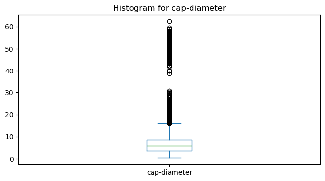

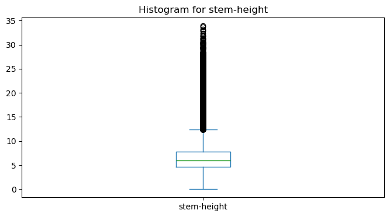

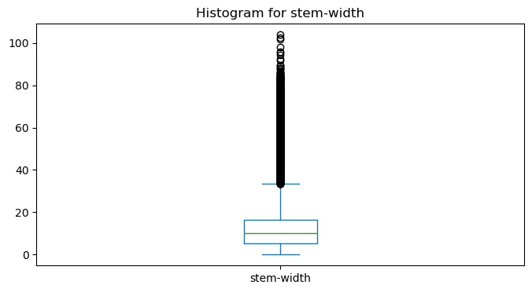

```python
for column in numerical_columns:
    fig, ax = plt.subplots(figsize=(8, 4))
    df[column].plot(kind='box', title=f"Histogram for {column}", ax=ax)
    plt.show()
```

By the box plot, we can see there are a lot of outlier in the positive side for all numerical columns.

```python
outliers_dict = dict()

for column in numerical_columns:
    # Calculate the first quartile (Q1) and third quartile (Q3)
    Q1 = df[column].quantile(0.25)
    Q3 = df[column].quantile(0.75)

    # Calculate the interquartile range (IQR)
    IQR = Q3 - Q1

    # Define the lower and upper bounds for outliers
    lower_bound = Q1 - 1.5 * IQR
    upper_bound = Q3 + 1.5 * IQR

    # Identify outliers
    outliers = df[(df[column] < lower_bound) | (df[column] > upper_bound)].loc[:,column]

    outliers_dict[column] = outliers.count()
```

```python
outliers_dict
```

```
{'cap-diameter': 2400, 'stem-height': 3169, 'stem-width': 1967}
```

Since the amount of outliers is small compare with the total rows, I will not remove any outliers. And I will use ensemble model. They are able to handle the outliers.

# Model Training and Evaluation